# Notes

Juan Malaver

March 28, 2020

# Exploratory Analysis

Importing the data:

```r
test.dockets <- read_csv("test_dockets.csv")
test.other <- read_csv("test_other_motions.csv")
test.termin <- read_csv("test_terminating_motions.csv")
train.dockets <- read_csv("train_dockets.csv")
train.other <- read_csv("train_other_motions.csv")
train.termin <- read_csv("train_terminating_motions.csv")
```

Creating a single column for outcome (0 = neither, 1 = summary judgment, 2 = settlement)

```r
train.dockets <- train.dockets %>%
  mutate(y = as.factor(ifelse(summary_judgment == 0 & settled == 0, 0, ifelse(summary_judgment == 1, 1, 2))))
```

I am using the following predictors for simple classification modelling: nos_code, district, issue_joined, days_opened, requested_damages_amt

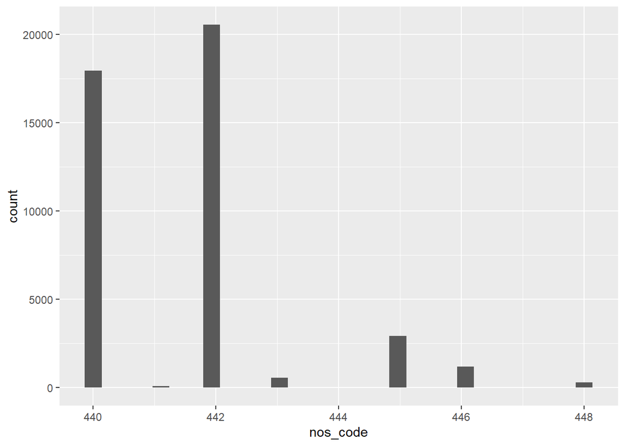

```r
ggplot(data = train.dockets) +
  geom_histogram(mapping = aes(x = nos_code))
```

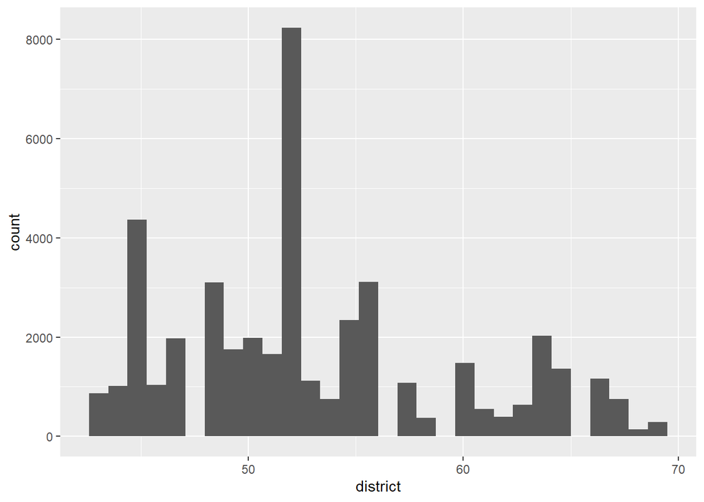

```r
ggplot(data = train.dockets) +
  geom_histogram(mapping = aes(x = district))
```

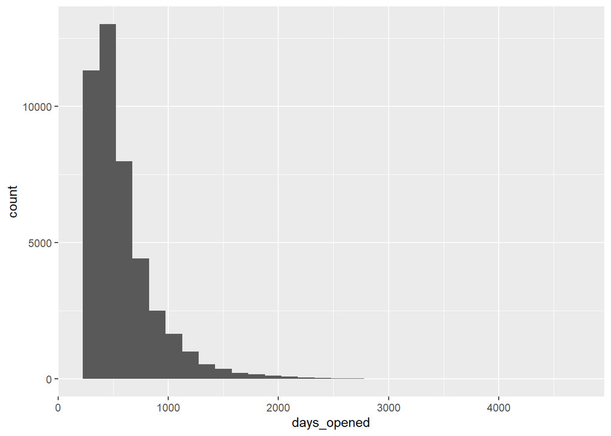

```r
ggplot(data = train.dockets) +
  geom_histogram(mapping = aes(x = days_opened))
```

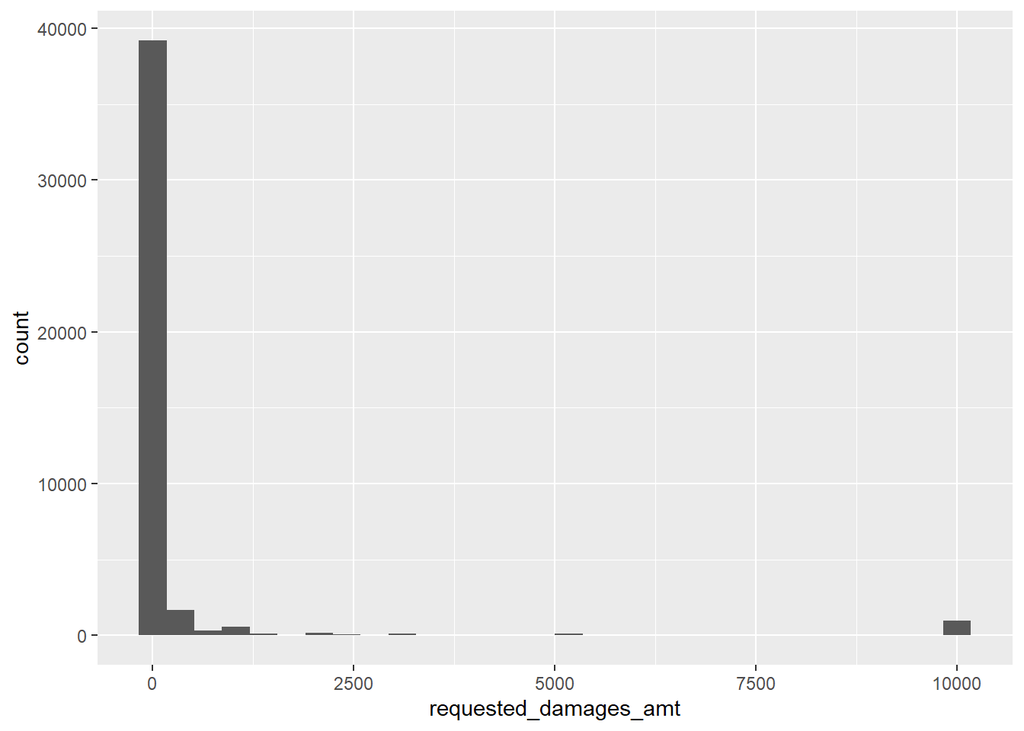

```r
ggplot(data = train.dockets) +
  geom_histogram(mapping = aes(x = requested_damages_amt))
```

Logistic Regression (binomial)

```r
glm.fit <- glm(y~as.factor(nos_code)+district+issue_joined+days_opened+requested_damages_amt, data=train.dockets, family = binomial)
summary(glm.fit)
```

```
##
## Call:
## glm(formula = y ~ as.factor(nos_code) + district + issue_joined +
##     days_opened + requested_damages_amt, family = binomial, data = train.dockets)
##
## Deviance Residuals:
##     Min       1Q   Median       3Q      Max
## -1.6437  -1.3406   0.8661   1.0017   1.3335
##
## Coefficients:
##                          Estimate Std. Error z value Pr(>|z|)
## (Intercept)             3.353e-01  8.845e-02   3.791  0.00015 ***
## as.factor(nos_code)441 -4.610e-01  2.071e-01  -2.226  0.02599 *
## as.factor(nos_code)442  3.952e-01  2.137e-02  18.494  < 2e-16 ***
## as.factor(nos_code)443 -6.095e-02  8.610e-02  -0.708  0.47903
## as.factor(nos_code)444  2.117e-01  4.851e-01   0.436  0.66250
## as.factor(nos_code)445  5.552e-01  4.324e-02  12.839  < 2e-16 ***
## as.factor(nos_code)446 -1.855e-02  6.074e-02  -0.305  0.76002
## as.factor(nos_code)448 -9.408e-02  1.198e-01  -0.786  0.43210
## district               -3.749e-03  1.546e-03  -2.424  0.01533 *
## issue_joinedTRUE        2.305e-01  2.045e-02  11.269  < 2e-16 ***
## days_opened             4.310e-05  3.120e-05   1.381  0.16717
## requested_damages_amt  -2.845e-05  6.187e-06  -4.599 4.25e-06 ***
## ---
## Signif. codes:  0 '***' 0.001 '**' 0.01 '*' 0.05 '.' 0.1 ' ' 1
##
## (Dispersion parameter for binomial family taken to be 1)
##
##     Null deviance: 57758  on 43569  degrees of freedom
## Residual deviance: 57110  on 43558  degrees of freedom
## AIC: 57134
##
## Number of Fisher Scoring iterations: 4
```

Linear Discriminant Analysis (simple)

```r
lda.fit <- lda(y~as.factor(nos_code)+district+issue_joined+days_opened+requested_damages_amt, data=train.dockets, subset = (year_filed < 2018))
lda.fit
```

```
## Call:
## lda(y ~ as.factor(nos_code) + district + issue_joined + days_opened +
##     requested_damages_amt, data = train.dockets, subset = (year_filed <
##     2018))
##
## Prior probabilities of groups:
##         0         1         2
## 0.3740166 0.2172218 0.4087616
##
## Group means:
##   as.factor(nos_code)441 as.factor(nos_code)442 as.factor(nos_code)443
## 0           0.0031327920              0.4212646            0.015344287
## 1           0.0027520916              0.5165125            0.008696609
## 2           0.0008190008              0.4973675            0.013104013
##   as.factor(nos_code)444 as.factor(nos_code)445 as.factor(nos_code)446
## 0           0.0004475417             0.05140336             0.03036890
## 1           0.0006605020             0.06693087             0.01497138
## 2           0.0002925003             0.07651808             0.02813853
##   as.factor(nos_code)448 district issue_joinedTRUE days_opened
## 0            0.007096733 53.22102        0.5557189    596.5931
## 1            0.005063849 53.20784        0.3654778    649.1304
## 2            0.005265005 52.93524        0.7341757    559.6808
##   requested_damages_amt
## 0              385.2717
## 1              347.0199
## 2              271.3351
##
## Coefficients of linear discriminants:
##                                  LD1           LD2
## as.factor(nos_code)441 -1.042118e+00  2.0479274659
## as.factor(nos_code)442 -6.728027e-02 -1.7979808824
## as.factor(nos_code)443  3.147165e-01  0.4742297576
## as.factor(nos_code)444 -5.269619e-01 -1.0915563846
## as.factor(nos_code)445  1.231220e-01 -2.4266101401
## as.factor(nos_code)446  5.471034e-01  0.4322670426
## as.factor(nos_code)448  2.943503e-02  0.4457107120
## district                1.401075e-02  0.0258077760
## issue_joinedTRUE        2.020220e+00 -0.0107267767
## days_opened            -1.147256e-03 -0.0005364975
## requested_damages_amt  -1.297163e-05  0.0001191669
##
## Proportion of trace:
##    LD1    LD2
## 0.8994 0.1006
```

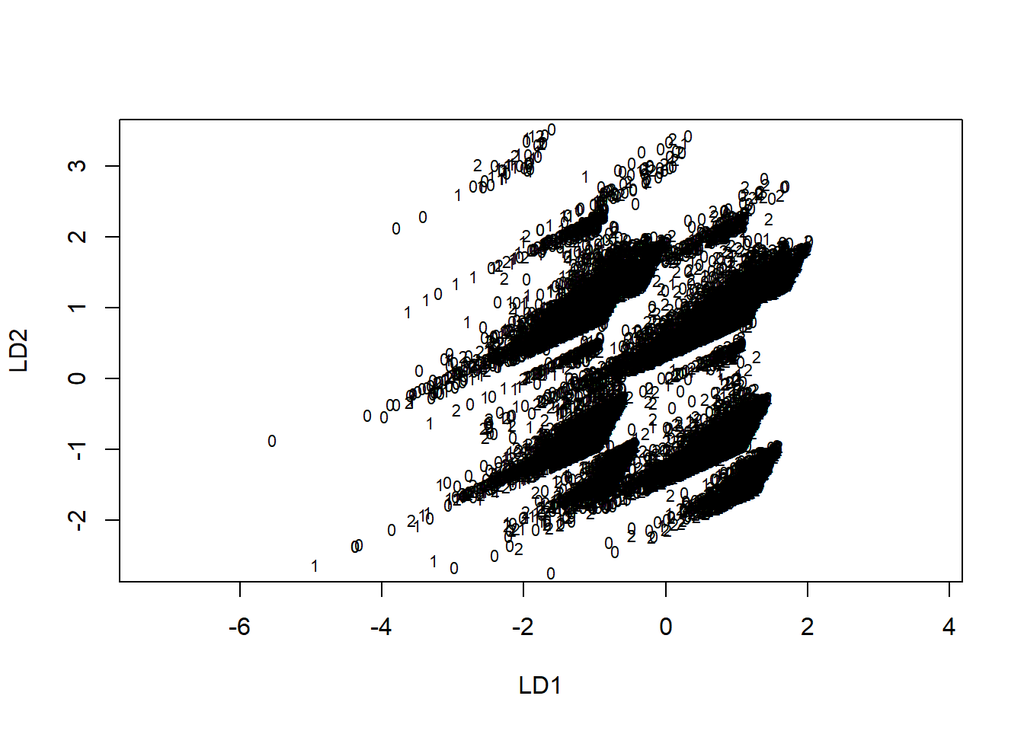

```r
plot(lda.fit)
```

Making predictions

```r
y.test <- deframe(train.dockets %>%
     filter(year_filed >= 2018) %>%
     dplyr::select(y))

lda.pred <- predict(lda.fit, train.dockets %>%
                      filter(year_filed >= 2018) %>%
                      dplyr::select(-y))
lda.class <- lda.pred$class
table(lda.class, y.test)
```

```
##          y.test
## lda.class   0   1   2
##         0 395 106 127
##         1  93  38  38
##         2 318  71 565
```

```r
mean(lda.class==y.test)
```

```
## [1] 0.56996
```

The model has about a 56% accuracy, but this is an example of how linear discriminant analysis can be conducted to make predictions.

What abouta quadratic discriminant analysis?

```r
qda.fit <- qda(y~as.factor(nos_code)+district+issue_joined+days_opened+requested_damages_amt, data=train.dockets, subset = (year_filed < 2018))
qda.fit
```

```
## Call:
## qda(y ~ as.factor(nos_code) + district + issue_joined + days_opened +
##     requested_damages_amt, data = train.dockets, subset = (year_filed <
##     2018))
##
## Prior probabilities of groups:
##         0         1         2
## 0.3740166 0.2172218 0.4087616
##
## Group means:
##   as.factor(nos_code)441 as.factor(nos_code)442 as.factor(nos_code)443
## 0           0.0031327920              0.4212646            0.015344287
## 1           0.0027520916              0.5165125            0.008696609
## 2           0.0008190008              0.4973675            0.013104013
##   as.factor(nos_code)444 as.factor(nos_code)445 as.factor(nos_code)446
## 0           0.0004475417             0.05140336             0.03036890
## 1           0.0006605020             0.06693087             0.01497138
## 2           0.0002925003             0.07651808             0.02813853
##   as.factor(nos_code)448 district issue_joinedTRUE days_opened
## 0            0.007096733 53.22102        0.5557189    596.5931
## 1            0.005063849 53.20784        0.3654778    649.1304
## 2            0.005265005 52.93524        0.7341757    559.6808
##   requested_damages_amt
## 0              385.2717
## 1              347.0199
## 2              271.3351
```

```r
qda.class <- predict(qda.fit, train.dockets %>%
                      filter(year_filed >= 2018) %>%
                      dplyr::select(-y))$class
table(qda.class, y.test)
```

```
##          y.test
## qda.class   0   1   2
##         0  95  22  54
##         1  18   9   2
##         2 693 184 674
```

```r
mean(qda.class==y.test)
```

```
## [1] 0.4443175
```

The quadratic model is less accurate! So we might be better off looking at some sort of linear classification model.

Lastly, what about K-Nearest Neighbors?

```r
attach(train.dockets)
train <- (year_filed < 2018)
train.X <- cbind(as.factor(nos_code),district,issue_joined,days_opened,requested_damages_amt)[train,]
test.X <- cbind(as.factor(nos_code),district,issue_joined,days_opened,requested_damages_amt)[!train,]
train.y <- y[train]
```

running model with k = 1

```r
set.seed(1)
knn.pred <- knn(train.X, test.X, train.y, k=1)
table(knn.pred, y.test)
```

```
##         y.test
## knn.pred   0   1   2
##        0 336  73 209
##        1 129  57  83
##        2 341  85 438
```

```r
(336+57+438)/1751
```

```
## [1] 0.474586
```

47% accuracy

k=3

```r
set.seed(1)
knn.pred <- knn(train.X, test.X, train.y, k=3)
table(knn.pred, y.test)
```

```
##         y.test
## knn.pred   0   1   2
##        0 348  77 188
##        1  97  41  87
##        2 361  97 455
```

```r
(348+41+455)/1751
```

```
## [1] 0.4820103
```

48% accuracy

Cross Validation (still working on this)

# Notes Medvedeva, Vols, Wieling

The authors find that analyzing legal texts for court proceedings will predict future decisions with 75% accuracy. We are not analyzing the text itself or using natural language processing but instead we can understand the different characteristics of each case and build a factor model from there.

They also found that predicting outcomes based only on the judges surname yiels 65% accuracy, which we can show by running models that are based on location predictors that imply a difference in the judge assigned to each case.

# General Notes

We are creating a model that predicts a category (verdict) associated to each element (case). This is a supervised machine learning approach. The computer identifies patterns that are associated with each outcome.

Westlaw, which is a product of Thomson Reuters has been compiling legal data for decade. The tools we can use in our analysis compine older legal methods of classification (deciding which predictors matter) and empirical quantitative tools (machine learning).